# Normalization performance report

- study: Illumina methylation data
- author: Analyst
- date: 26 March, 2018

## Parameters used to test normalization

```
## $variables
## [1] "Slide"       "Sex"         "sentrix_row" "sentrix_col" "Age"
##
## $control.pcs
##  [1]  1  2  3  4  5  6  7  8  9 10 11 12 13 14 15
##
## $batch.pcs
##  [1]  1  2  3  4  5  6  7  8  9 10 11 12 13 14 15
##
## $batch.threshold
## [1] 0.01
##
## $colours
## NULL
```

## Control probe scree plots

The variance captured by each principal component.

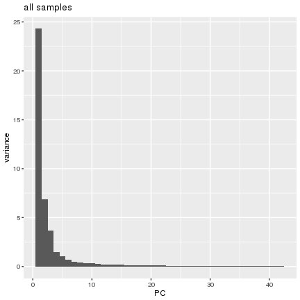

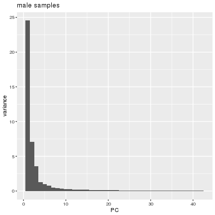

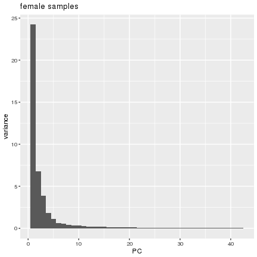

## Principal components of the control probes

The following plots show the first 3 principal components of the control matrix colored by batch variables. Batch variables with more than 10 levels are omitted.

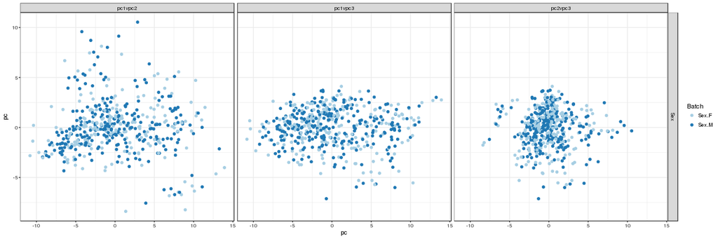

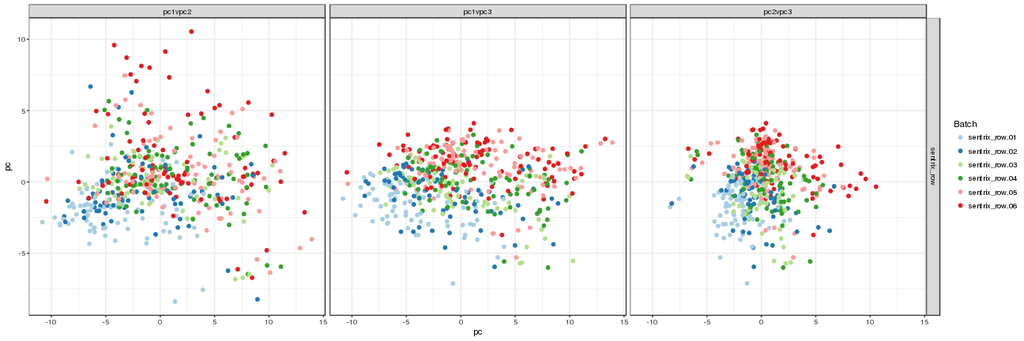

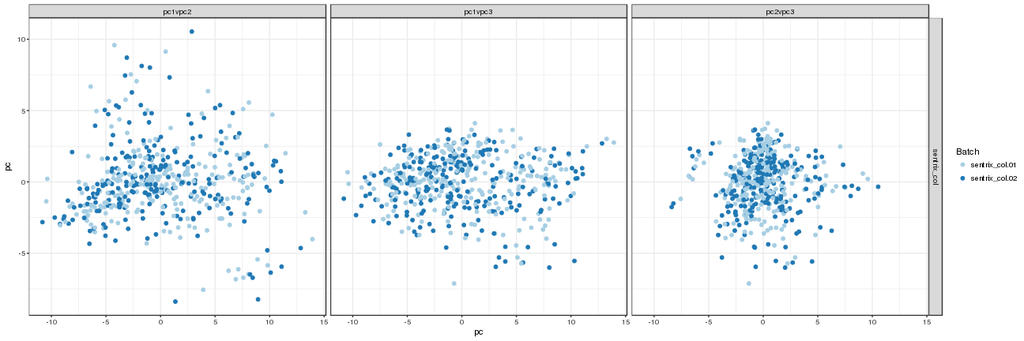

## Control probe associations with measured batch variables

Principal components of the control probes were regressed against batch variables. Shown are the \(-log_{10}\) p-values for these regressions. The horizontal dotted line denotes \(p = 0.05\) in log-scale.

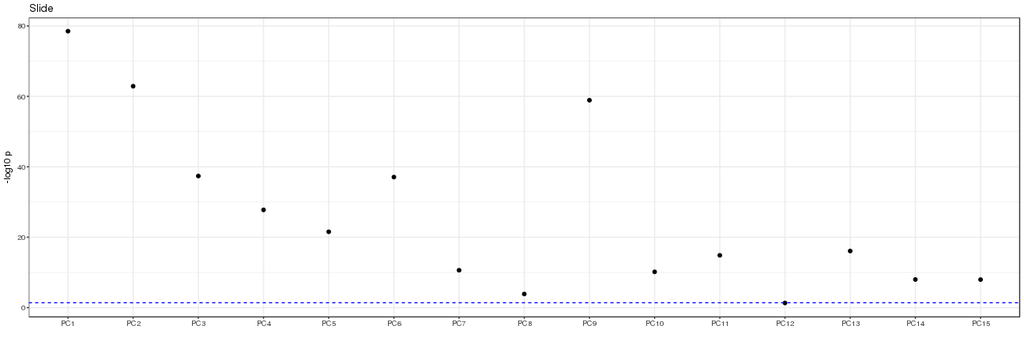

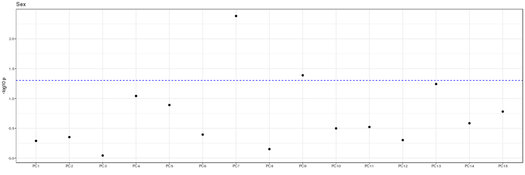

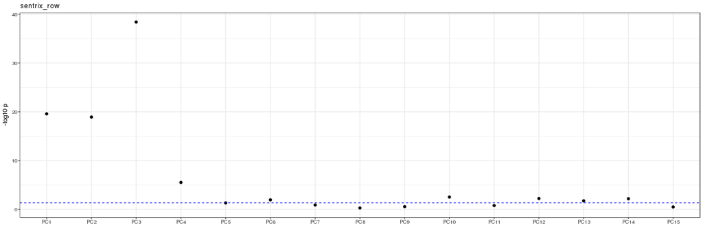

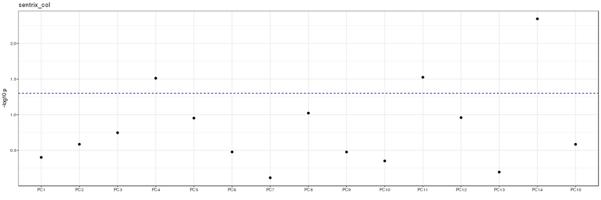

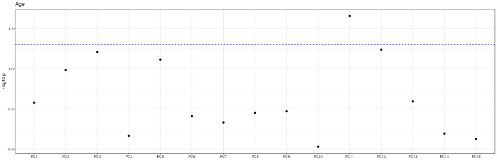

The following plots show regression coefficients when each principal component is regressed against each batch variable level along with 95% confidence intervals. Cases significantly different from zero are coloured red (p < 0.01, t-test).

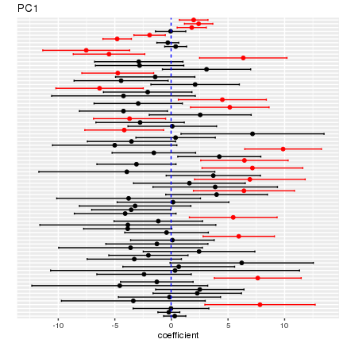

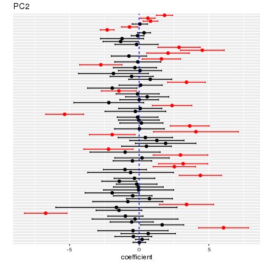

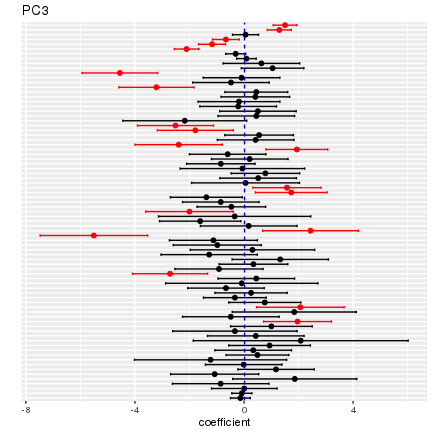

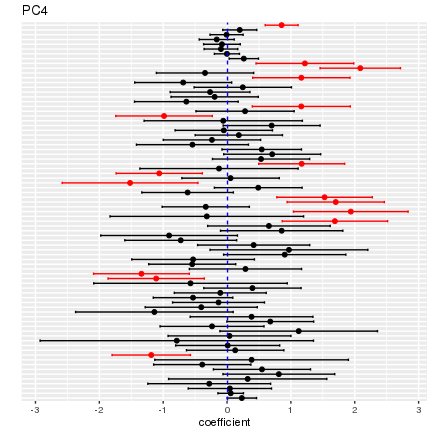

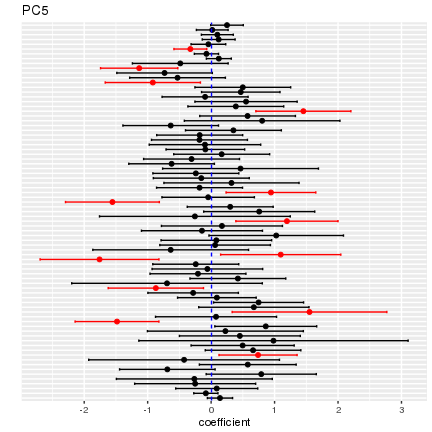

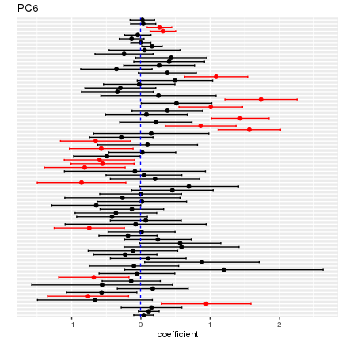

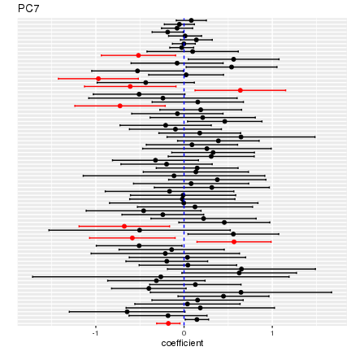

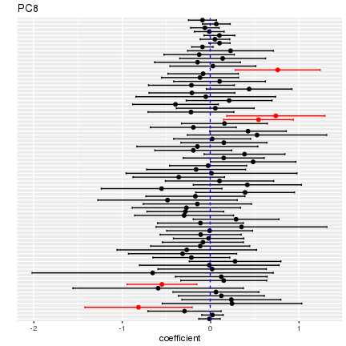

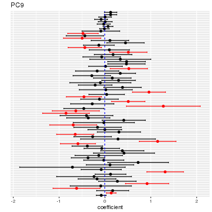

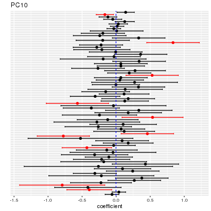

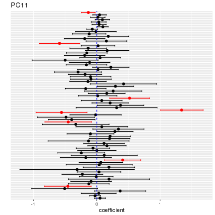

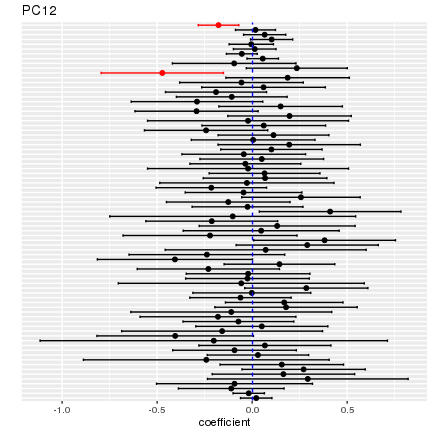

[3 more figures not shown]

| batch.variable | batch.value | principal.component | test | p.value | estimate | lower | upper |
| --- | --- | --- | --- | --- | --- | --- | --- |
| Slide |  | PC1 | F-test | 3.07e-79 | 15.412 |  |  |
| Slide | 3999979002 | PC1 | t-test | 3.48e-04 | 7.827 | 2.9548 | 12.6995 |
| Slide | 3999984023 | PC1 | t-test | 1.03e-05 | 7.629 | 3.7921 | 11.4656 |
| Slide | 3999984053 | PC1 | t-test | 2.77e-05 | 5.949 | 2.7985 | 9.1001 |
| Slide | 3999984065 | PC1 | t-test | 1.68e-03 | 5.461 | 1.5867 | 9.3357 |
| Slide | 3999984139 | PC1 | t-test | 1.37e-03 | 6.408 | 1.9441 | 10.8715 |
| Slide | 3999984145 | PC1 | t-test | 1.57e-03 | 6.930 | 2.0439 | 11.8164 |
| Slide | 3999984150 | PC1 | t-test | 3.46e-04 | 7.155 | 2.7030 | 11.6071 |
| Slide | 3999984153 | PC1 | t-test | 2.00e-04 | 6.450 | 2.5913 | 10.3091 |
| Slide | 3999984156 | PC1 | t-test | 1.67e-10 | 9.868 | 6.4799 | 13.2569 |
| Slide | 3999997043 | PC1 | t-test | 7.52e-03 | -4.170 | -7.6514 | -0.6878 |
| Slide | 3999997053 | PC1 | t-test | 9.57e-03 | -3.698 | -6.8840 | -0.5121 |
| Slide | 3999997071 | PC1 | t-test | 9.25e-04 | 5.157 | 1.6888 | 8.6252 |
| Slide | 3999997084 | PC1 | t-test | 9.74e-03 | 4.500 | 0.6127 | 8.3870 |
| Slide | 3999997087 | PC1 | t-test | 2.53e-04 | -6.349 | -10.2096 | -2.4884 |
| Slide | 3999997099 | PC1 | t-test | 8.71e-04 | -4.741 | -7.9130 | -1.5695 |
| Slide | 3999997159 | PC1 | t-test | 2.54e-04 | 6.347 | 2.4865 | 10.2077 |
| Slide | 9721366162 | PC1 | t-test | 1.04e-04 | -5.515 | -8.6737 | -2.3559 |
| Slide | 9721367028 | PC1 | t-test | 1.36e-05 | -7.527 | -11.3659 | -3.6883 |
| sentrix_row |  | PC1 | F-test | 2.63e-20 | 22.481 |  |  |
| sentrix_row | 01 | PC1 | t-test | 2.42e-16 | -4.794 | -6.0516 | -3.5361 |
| sentrix_row | 02 | PC1 | t-test | 2.05e-03 | -1.929 | -3.3166 | -0.5414 |
| sentrix_row | 04 | PC1 | t-test | 2.02e-03 | 1.795 | 0.5070 | 3.0832 |
| sentrix_row | 05 | PC1 | t-test | 2.29e-05 | 2.404 | 1.1526 | 3.6557 |
| sentrix_row | 06 | PC1 | t-test | 5.68e-04 | 1.966 | 0.7044 | 3.2275 |
| Slide |  | PC2 | F-test | 1.33e-63 | 11.793 |  |  |
| Slide | 3999979005 | PC2 | t-test | 1.85e-13 | 6.054 | 4.2644 | 7.8443 |
| Slide | 3999984023 | PC2 | t-test | 6.41e-21 | -6.715 | -8.2432 | -5.1867 |
| Slide | 3999984028 | PC2 | t-test | 1.06e-04 | 3.397 | 1.4484 | 5.3461 |
| Slide | 3999984057 | PC2 | t-test | 2.26e-10 | 4.392 | 2.8740 | 5.9098 |

[output cut: 184 more lines]

## Principal components of the normalized betas

The following plots show the first 3 principal components of the most variable probes colored by batch variables. Batch variables with more than 10 levels are omitted.

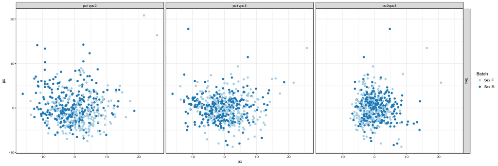

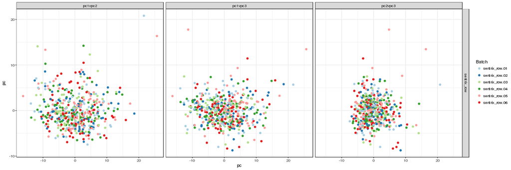

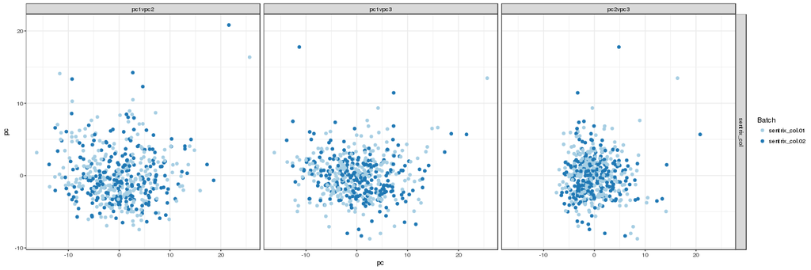